# 共享单车用户满意度分析

#### 4.4受访用户在不同城区的分数差异

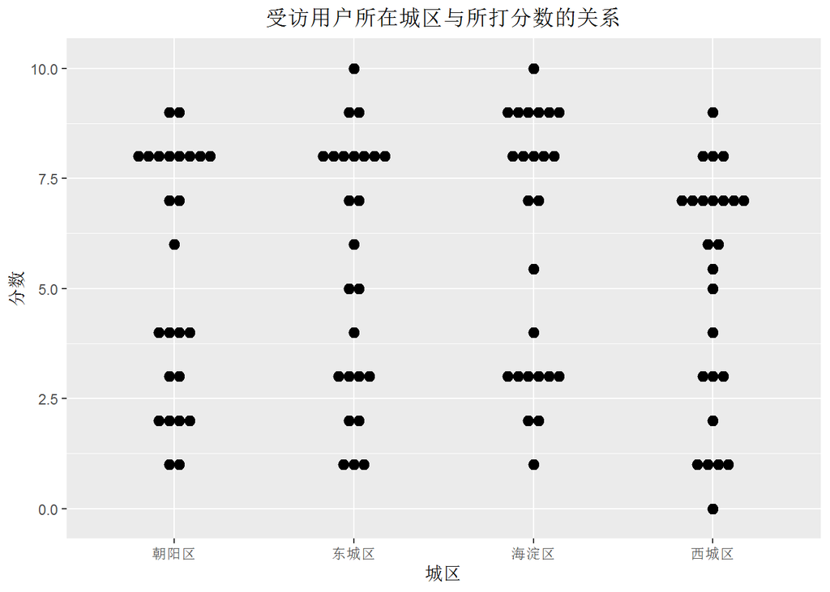

```r
#查看对照组和实验组的分数差异
#设定new.cus.data为画图的数据，设定xy轴分别为城区、分数
g1<-ggplot(data=new.cus.data,aes(x=城区,y=分数))+
   geom_dotplot(binaxis="y",stackdir="center",dotsize = 0.7)+ #dotsize设置dot的大小，默认为1
   ggtitle(paste( "受访用户所在城区与所打分数的关系"))+ #加标题
   #设置title居中呈现
   theme(plot.title = element_text(hjust = 0.5))
g2<-ggplot(new.cus.data, aes(城区,分数))+
   geom_boxplot()+
   ggtitle(paste( "不同城区的受访用户所给分数的平均分对比"))+
   #设置title居中呈现
   theme(plot.title = element_text(hjust = 0.5))
g1
```

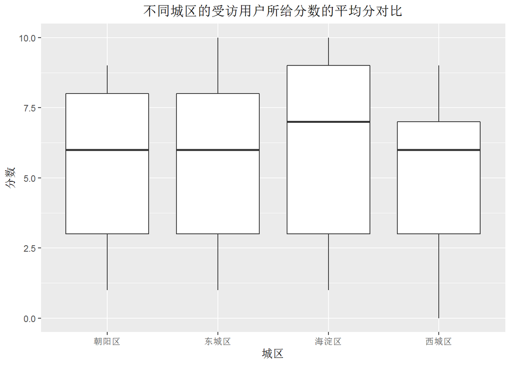

```r
g2
```

```r
# #加载Rmisc包
# library(Rmisc)
# #将g1 g2两个图并排展示
# multiplot(g1,g2,cols=2)
# 由于并排显示的图像较为拥挤故竖排显示图像
```

根据图表，海淀区用户的打分情况可能比其他城区好，下面求各个城区的平均分看一下

```r
#求出各个城区的平均分
average.data <- new.cus.data %>%
  group_by(城区) %>%
dplyr::  summarise(平均分数 = mean(分数))
average.data
```

```
## # A tibble: 4 x 2
##   城区   平均分数
##   <fct>     <dbl>
## 1 朝阳区     5.36
## 2 东城区     5.48
## 3 海淀区     6.02
## 4 西城区     4.94
```

由此可以看出四个城区的用户中，海淀区用户所给分数的平均分相对高些，说明海淀区用户对共享单车的满意度更高，可能跟海淀区高校多、互联网公司多、单车数量多等因素有关

#### 4.5采访时间与分数的关系

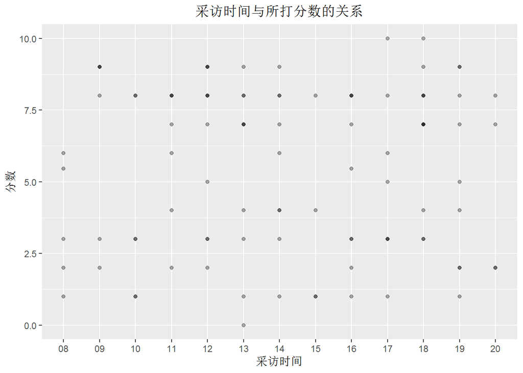

```r
#判断采访时间与所打分数之间是否存在关系
ggplot(data = new.cus.data, aes(采访时间,分数)) + geom_point(alpha= 1/3) + labs(title = "采访时间与所打分数的关系") + theme(plot.title = element_text(hjust = 0.5))#设置标题居中
```

由此可见，用户的采访时间与所打分数并无太大的关系

#### 4.6月收入与分数的关系

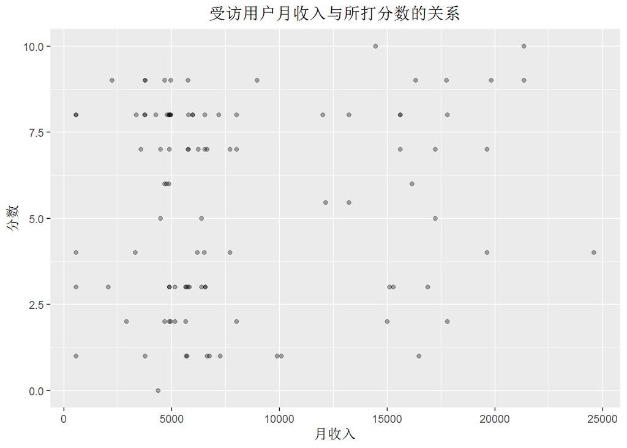

```r
ggplot(data = new.cus.data,aes(月收入,分数)) + geom_point(alpha = 1/3) +
labs(title = "受访用户月收入与所打分数的关系") + theme(plot.title = element_text(hjust = 0.5))
```

没有发现受访用户月收入与所打分数之间的明显关系，看起来在受访用户中， 月收入10000以下的用户多于月收入10000以上的用户

#### 4.7年龄与分数的关系

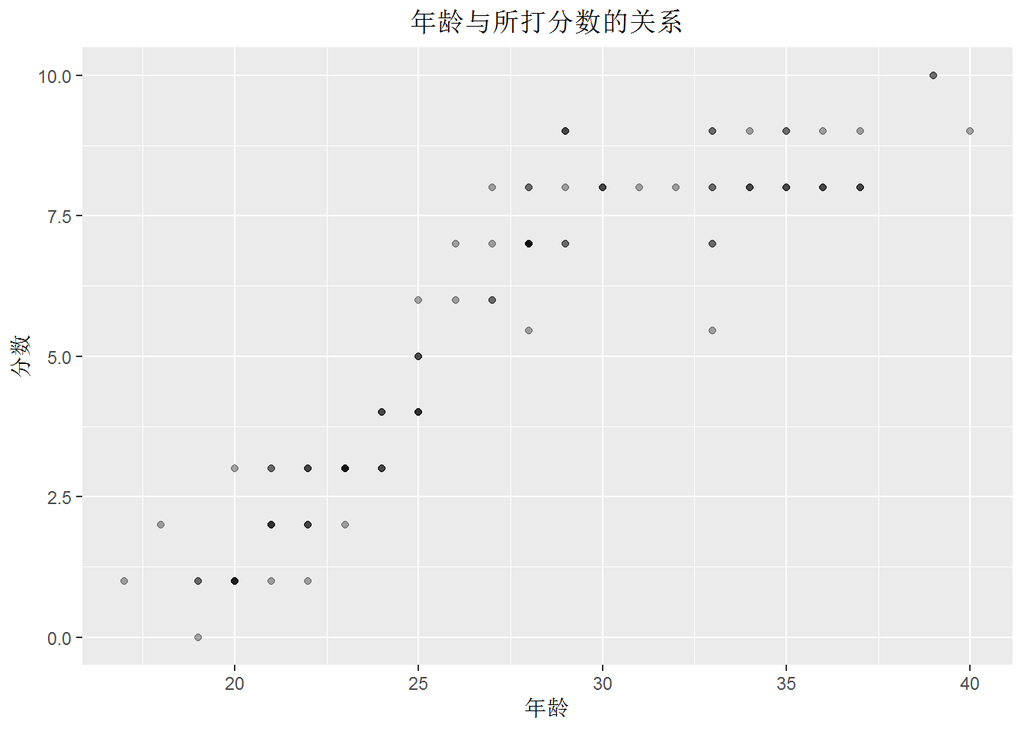

```r
#判断年龄与所打分数的关系
ggplot(new.cus.data,aes(年龄,分数)) + geom_point(alpha = 1/3) + labs(title = "年龄与所打分数的关系") + theme(plot.title = element_text(hjust = 0.5))
```

整体来看，年龄高的用户给出的分数高于年龄低的用户。在30岁以下用户群体中，用户所打的分数随着用户年龄的增加也呈线性关系增长；30岁以上的用户群体中，用户所打分数不再随着年龄增加而增加，这应该与分数最高为10分有关。

#### 4.8不同城区各年龄段所打分数的差异

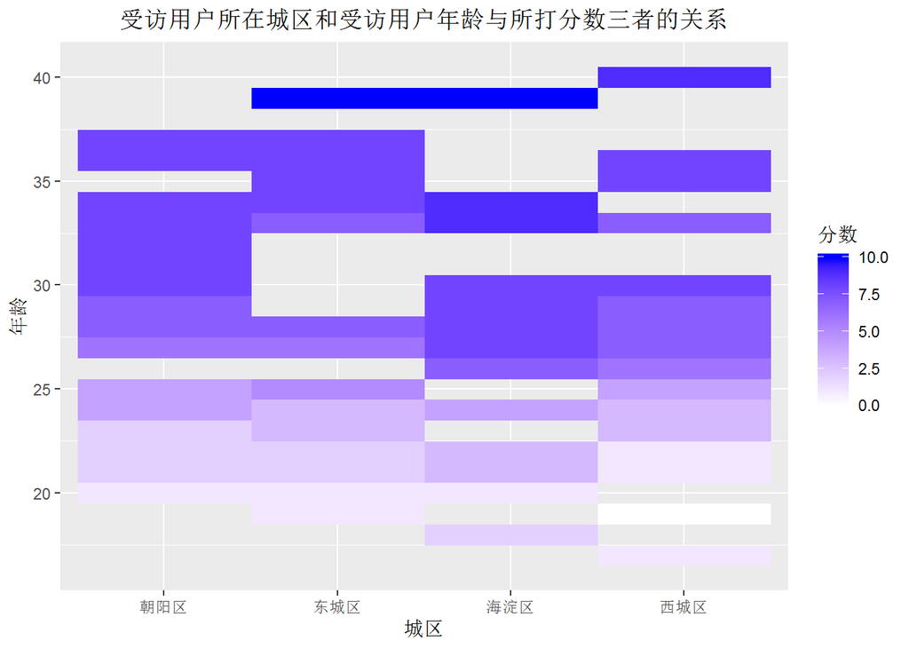

```r
#采用热力图分离三者之间的关系
g<-ggplot(new.cus.data,aes(x=城区,y=年龄))
g+ geom_raster(aes(fill=分数))+
   #默认颜色为低分深色高分浅色，调整为低分浅色高分深色
   scale_fill_gradientn(colours=c("#FFFFFFFF","blue"))+
   ggtitle(paste( "受访用户所在城区和受访用户年龄与所打分数三者的关系"))+
   #设置title居中呈现
   theme(plot.title = element_text(hjust = 0.5))
```

相对于城区，分数的高低更依赖于年龄的大小

### 5. 分析与建模

#### 5.1 满意分影响因素

##### 5.1.1 决策树方法

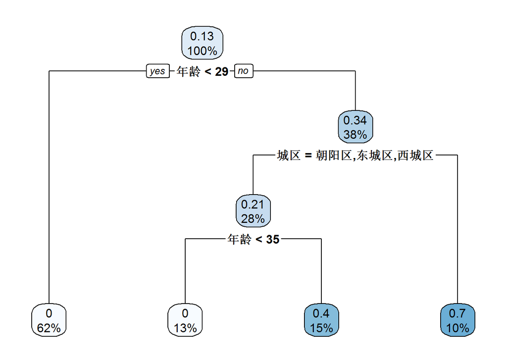

```r
#install.packages("rpart")
#install.packages("rpart.plot")
#设置推荐者为分数>=9的值
new.cus.data$推荐者 <- new.cus.data$分数 >= 9
library(rpart)
library(rpart.plot)
rtree_fit<-rpart(推荐者 ~ 城区+年龄+组别,data=new.cus.data)
rpart.plot(rtree_fit)
```

年龄大于29岁的海淀区用户推荐者比例最高

##### 5.1.2 线性回归方法

###### 步骤1：识别多重共线性对模型的干扰

```r
#install.packages("GGally")
library(GGally)
```

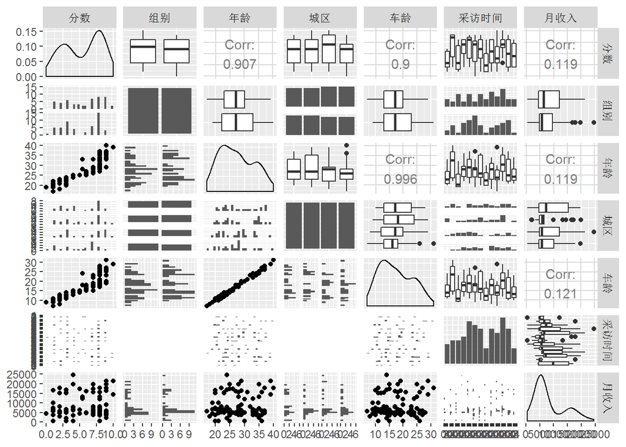

```r
ggpairs(new.cus.data, columns = c("分数","组别","年龄","城区","车龄","采访时间","月收入"))
```

受访用户的年龄与车龄强相关，解决方法：去除车龄变量，保留年龄变量

###### 步骤2：检查多重共线性是否依然存在

```r
#install.packages("car")
#消除多重共线性之前
lm_fit <- lm(分数 ~ 城区+年龄+组别+车龄+采访时间+月收入, data = new.cus.data)#lm()是线性回归方程
library(car)
vif(lm_fit)
```

```
##                GVIF Df GVIF^(1/(2*Df))
## 城区       1.527984  3        1.073214
## 年龄     893.107082  1       29.884897
## 组别       1.174977  1        1.083964
## 车龄     896.641964  1       29.943980
## 采访时间  16.201276 12        1.123047
## 月收入     1.146504  1        1.070749
```

```r
#消除多重共线性之后
lm_fit <- lm(分数 ~ 城区+年龄+组别+采访时间+月收入, data = new.cus.data)#lm()是线性回归方程
library(car)
vif(lm_fit)
```

```
##              GVIF Df GVIF^(1/(2*Df))
## 城区     1.514915  3        1.071679
## 年龄     1.198474  1        1.094748
## 组别     1.168501  1        1.080972
## 采访时间 2.079720 12        1.030980
## 月收入   1.111259  1        1.054163
```

通过GVIF值可见，已消除多重共线性

###### 步骤3：挑选模型输入自变量

```r
#install.packages("olsrr")
library(olsrr)
model <- lm(分数 ~ 城区+年龄+组别+采访时间+月收入, data = new.cus.data)

k <- ols_step_all_possible(model)

k <- as.data.frame(k)#为了使k能够在文档中显示故将其转化为数据框结构

k
```

```
##    mindex n                     predictors     rsquare          adjr
## 2       1 1                           年龄 0.822404214  8.205920e-01
## 4       2 1                       采访时间 0.121281153  7.855287e-05
## 1       3 1                           城区 0.018503055 -1.216872e-02
## 5       4 1                         月收入 0.014200540  4.141361e-03
## 3       5 1                           组别 0.009018446 -1.093611e-03
## 6       6 2                      城区 年龄 0.858319712  8.523542e-01
## 10      7 2                      年龄 组别 0.846928002  8.437719e-01
## 11      8 2                  年龄 采访时间 0.836995905  8.123558e-01
## 12      9 2                    年龄 月收入 0.822522870  8.188635e-01
## 13     10 2                  组别 采访时间 0.147741869  1.891215e-02
## 8      11 2                  城区 采访时间 0.142525057 -1.059547e-02
## 15     12 2                采访时间 月收入 0.127698664 -4.160840e-03
## 9      13 2                    城区 月收入 0.031131189 -9.663287e-03
## 7      14 2                      城区 组别 0.027458266 -1.349086e-02
```

[output cut: 81 more lines]

```r
#选出调整R^2最大的分组


max.id <- k[k$adjr == max(k$adjr),"predictors"]
max.id
```

```
## [1] "城区 年龄 组别"
```

根据调整R^2的大小选出最优变量的组合为 城区+年龄+组别

##### 步骤4：运行线性回归模型

```r
result <- lm(分数 ~ 城区+年龄+组别, data = new.cus.data)
summary(result)
```

```
##
## Call:
## lm(formula = 分数 ~ 城区 + 年龄 + 组别, data = new.cus.data)
##
## Residuals:
##     Min      1Q  Median      3Q     Max
## -3.9070 -0.5910 -0.0802  0.8077  2.0549
##
## Coefficients:
##             Estimate Std. Error t value Pr(>|t|)
## (Intercept) -7.05987    0.53808 -13.121  < 2e-16 ***
## 城区东城区  -0.08223    0.28459  -0.289    0.773
## 城区海淀区   1.24847    0.28556   4.372 3.18e-05 ***
## 城区西城区   0.27878    0.28594   0.975    0.332
## 年龄         0.45962    0.01766  26.024  < 2e-16 ***
## 组别实验组  -0.86427    0.20171  -4.285 4.42e-05 ***
## ---
## Signif. codes:  0 '***' 0.001 '**' 0.01 '*' 0.05 '.' 0.1 ' ' 1
##
## Residual standard error: 1.006 on 94 degrees of freedom
## Multiple R-squared:  0.8815, Adjusted R-squared:  0.8752
## F-statistic: 139.8 on 5 and 94 DF,  p-value: < 2.2e-16
```

#### 5.2 用户画像——K-Means

##### 步骤1：

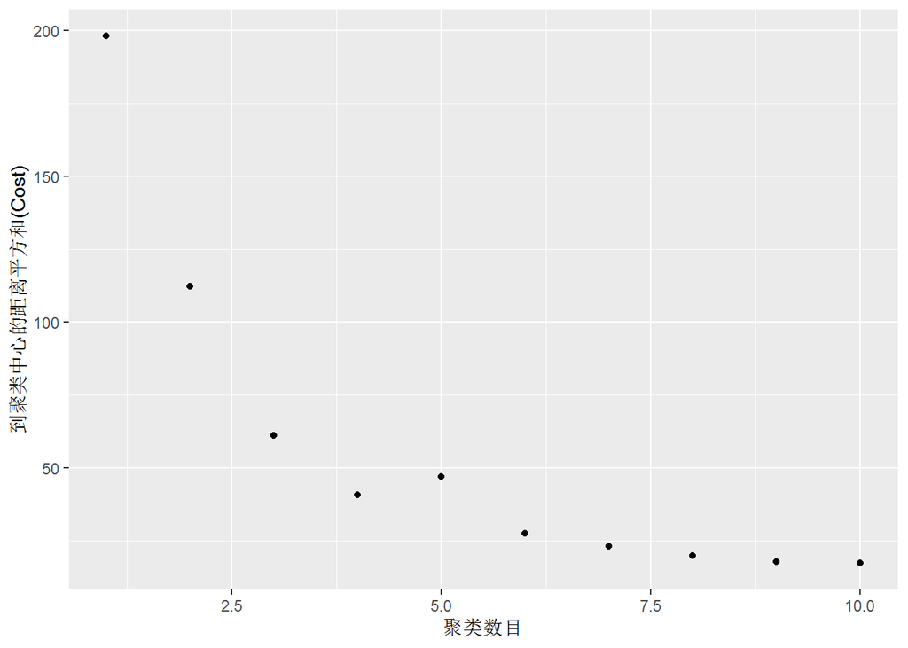

```r
#肘部法则用来判断聚类的K值大小
set.seed(1)#确定随机数生成函数的初始数，可使下面kmeans的结果在不同运行过程中重现
cost.df <- data.frame()
for(k in 1:10){
  kmeans.fit <- kmeans(x=scale(new.cus.data[, c("月收入","年龄")]),centers=k)#对每一个聚类数目选择k，进行k-means聚类
  cost.df <- rbind(cost.df, cbind(k, kmeans.fit$tot.withinss))#提取聚类结果得到的“到聚类中心的举例平方和（cost）”
}
names(cost.df) <- c("y","n")#对两列重命名
ggplot(cost.df, aes(y,n))+
  geom_point()+
  xlab("聚类数目")+
  ylab("到聚类中心的距离平方和(Cost)")
```

选取聚类数目为5

##### 步骤2:运行K-means模型

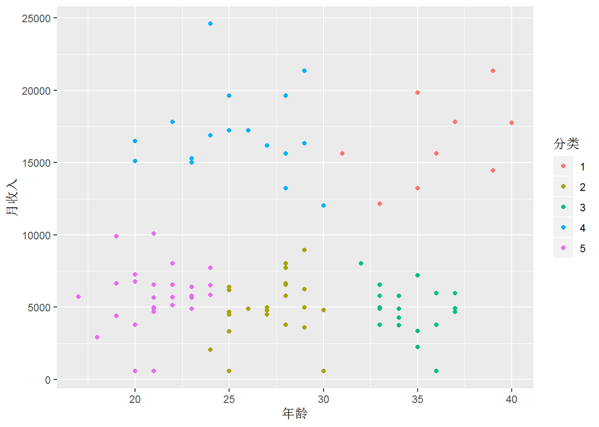

```r
set.seed(1)#确定随机数生成函数的初始数，可使下面kmeans的结果在不同运行过程中重现
kmeans_cluster <- kmeans(scale(new.cus.data[, c("月收入","年龄")]),5)# kmeans()方差运行算法，选取聚类数目k=5
new.cus.data$分类 <- as.factor(kmeans_cluster$cluster) #重命名生成的新标签为中文
#画图
library(ggplot2)
ggplot(new.cus.data, aes(年龄,月收入,color=分类))+geom_point()
```

##### 步骤3:总结聚类结果

```r
## 生成用户画像的数据
library(dplyr)
new.cus.data %>%
  group_by(分类) %>%
dplyr::summarise(平均月收入=mean(月收入), 平均分数=mean(分数))
```

```
## # A tibble: 5 x 3
##   分类  平均月收入 平均分数
##   <fct>      <dbl>    <dbl>
## 1 1         16423.     8.38
## 2 2          5009.     6.5
## 3 3          4812.     8.2
## 4 4         17039.     5.03
## 5 5          5643.     2.13
```

#### 5.3 ABtest(A/B测试)

在不同时期的新用户可能被收取￥99押金或免除押金，收取押金用户为实验组用户，其他用户为对照组用户。设计实验分析此次“收押金”，对用户的满意度分数有没有影响？

##### 5.3.1ABtest-双样品z-检验（平均值）

假设H0：收取押金对用户的满意度没有影响；假设H1：收取押金对用户的满意度有影响

```r
#进行双侧检验
library(BSDA)
s1 <- new.cus.data[new.cus.data$组别=="实验组","分数"]

s2 <- new.cus.data[new.cus.data$组别=="对照组","分数"]

result <- z.test(x=s1,sigma.x = sd(s1,na.rm = TRUE),y=s2,sigma.y = sd(s2,na.rm = TRUE),alternative = "two.sided")

result
```

```
##
##  Two-sample z-Test
##
## data:  s1 and s2
## z = -0.94438, p-value = 0.345
## alternative hypothesis: true difference in means is not equal to 0
## 95 percent confidence interval:
##  -1.6544401  0.5785218
## sample estimates:
## mean of x mean of y
##  5.180000  5.717959
```

通过ABtest-双样品z-检验（平均值）的结果来看，p-value = 0.345 > 显著性水平0.05。因此，基于此次假设检验，我们无法拒绝原假设H0，收取押金对用户的满意度分数没有显著影响。

##### 5.3.2ABtest-双样品z-检验（比例）

假设H0：收取押金对用户的满意度没有影响；假设H1：收取押金对用户的满意度有影响

```r
#table函数生成透视表，查看组别vs推荐者两个变量之间的关系
tou <- table(new.cus.data$组别,new.cus.data$推荐者)
#双样品z-检验
prop.test(tou, alternative="two.sided")
```

```
##
##  2-sample test for equality of proportions with continuity correction
##
## data:  tou
## X-squared = 3.183, df = 1, p-value = 0.07441
## alternative hypothesis: two.sided
## 95 percent confidence interval:
##  -0.288941203  0.008941203
## sample estimates:
## prop 1 prop 2
##   0.80   0.94
```

通过ABtest-双样品z-检验（比例）的结果来看，p-value = 0.07441 > 显著性水平0.05。基于0.05显著性水平来看，我们无法拒绝原假设H0。 但如果按照0.1显著性水平，收取押金会对用户稍稍有一点影响，应谨慎对待。